# Final Tuturiol

Introduction In this tuturiol, I will anaylze the relationship between school enrollments and county and time. By anaylzing this dataset, we can test our hypothesis to see if there is a dependence relationship between county and enrollment rates and overall if there is an trend in school enrollments. The following dataset is from https://opendata.maryland.gov/api/views/9ju3-j8k6/rows.csv?accessType=DOWNLOAD, sourced from Maryland State Department of Education. Data are grouped by Pre-Kindergarten (Pre-K), Kindergarten through Grade 5 (K-5), Grades 6-8, and Grades 9-12. Data is from 2009-2019.

```python
import pandas as pd
import matplotlib.pyplot as plt
from sklearn.linear_model import LinearRegression
from sklearn.metrics import mean_squared_error, r2_score
import numpy as np

data = pd.read_csv("Maryland_Public_School_Enrollment_Trends__Pre-Kindergarten_to_Grade_12__2009-2019.csv")
data.drop(['Date Created'], axis=1, inplace=True)
data.head()
```

|  | Grades | Year | Baltimore City | Allegany County | Anne Arundel County | Baltimore County | Calvert County | Caroline County | Carroll County | Cecil County | ... | Montgomery County | Prince George's County | Queen Anne's County | St. Mary's County | Somerset County | Talbot County | Washington County | Wicomico County | Worcester County | Maryland |
| --- | --- | --- | --- | --- | --- | --- | --- | --- | --- | --- | --- | --- | --- | --- | --- | --- | --- | --- | --- | --- | --- |
| 0 | 6-8 | 2009 | 16544 | 2019 | 16579 | 22366 | 3916 | 1155 | 6330 | 3648 | ... | 30996 | 27243 | 1738 | 3763 | 580 | 939 | 5042 | 2947 | 1415 | 185387 |
| 1 | 9-12 | 2009 | 24152 | 2796 | 23005 | 31952 | 5764 | 1660 | 9425 | 5053 | ... | 45164 | 40395 | 2462 | 5289 | 807 | 1459 | 6478 | 4132 | 2189 | 266628 |
| 2 | K-5 | 2009 | 37458 | 3878 | 33493 | 45423 | 6973 | 2409 | 11680 | 6919 | ... | 62136 | 53270 | 3312 | 7391 | 1320 | 1876 | 9894 | 6973 | 2674 | 367621 |
| 3 | Pre-K | 2009 | 4712 | 459 | 1699 | 3585 | 353 | 327 | 286 | 585 | ... | 3426 | 6139 | 281 | 743 | 191 | 221 | 488 | 567 | 381 | 28626 |
| 4 | 6-8 | 2010 | 16659 | 1952 | 16782 | 22574 | 3847 | 1126 | 6138 | 3592 | ... | 30860 | 26577 | 1681 | 3760 | 567 | 907 | 5059 | 2998 | 1455 | 184068 |

5 rows × 27 columns

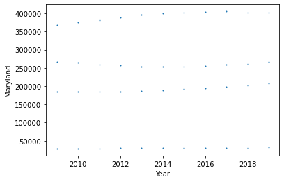

```
Grades
6-8      191670.000000
9-12     259121.727273
K-5      393268.909091
Pre-K     30206.818182
Name: Maryland, dtype: float64
```

```python
fig, ax = plt.subplots()
data.groupby('Year').plot.scatter(x='Year', y='Maryland', s=1, ax=ax)
plt.show()
data.groupby('Grades')["Maryland"].mean()
```

The graph above tells us different age group has different school enrollments numbers, and how the numbers change over 2009-2019.

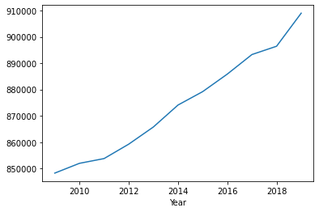

```python
sumtable = data.groupby('Year').sum()
sumtable['Maryland'].plot(x='Year', y='Maryland')
plt.show()
```

This graph shows us how students enrollment numbers(including all age groups) changes over the time, and it also shows that there is an increasing trend of enrollemnt.

```python
grades = data["Grades"].unique()
years = data['Year'].unique()
```

Each graph below is an age group, and each one shows how its enrollent number changes over time. Each graph has an regression line that shows if there is an dependence relationship between time and enrollment number.

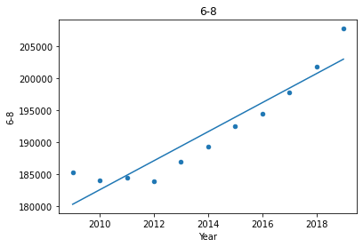

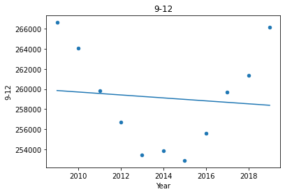

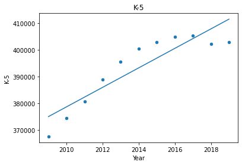

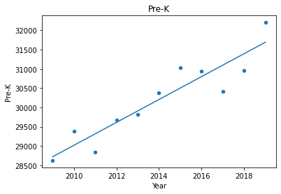

```python
grouped=data.groupby('Grades')['Maryland'].apply(pd.DataFrame)
df = pd.DataFrame(data={})
for grade in grades:
    df[grade] = grouped[grade].dropna().reset_index(drop=True)
df['Year'] = years
for g in grades:
    df.plot.scatter(x='Year', y=g,title=g)
    #regression line
    m,b = np.polyfit(df['Year'],df[g],1)
    plt.plot(df['Year'], m*df['Year'] + b)
```

```python
sumtable.drop('Maryland',axis=1,inplace=True)
sumtable.head()
```

| Year | Baltimore City | Allegany County | Anne Arundel County | Baltimore County | Calvert County | Caroline County | Carroll County | Cecil County | Charles County | Dorchester County | ... | Kent County | Montgomery County | Prince George's County | Queen Anne's County | St. Mary's County | Somerset County | Talbot County | Washington County | Wicomico County | Worcester County |
| --- | --- | --- | --- | --- | --- | --- | --- | --- | --- | --- | --- | --- | --- | --- | --- | --- | --- | --- | --- | --- | --- |
| 2009 | 82866 | 9152 | 74776 | 103326 | 17006 | 5551 | 27721 | 16205 | 26779 | 4628 | ... | 2184 | 141722 | 127047 | 7793 | 17186 | 2898 | 4495 | 21902 | 14619 | 6659 |
| 2010 | 83800 | 9022 | 75481 | 104160 | 16795 | 5517 | 27334 | 15937 | 26850 | 4647 | ... | 2183 | 144023 | 126671 | 7781 | 17271 | 2920 | 4504 | 22206 | 14382 | 6699 |
| 2011 | 84212 | 8913 | 76303 | 105153 | 16553 | 5545 | 27082 | 15827 | 26778 | 4647 | ... | 2162 | 146459 | 123833 | 7761 | 17449 | 2882 | 4547 | 22240 | 14520 | 6643 |
| 2012 | 84747 | 8929 | 77770 | 106927 | 16323 | 5585 | 26687 | 15634 | 26644 | 4718 | ... | 2130 | 148780 | 123737 | 7752 | 17453 | 2943 | 4570 | 22403 | 14489 | 6650 |
| 2013 | 84730 | 8872 | 78489 | 108191 | 16221 | 5545 | 26331 | 15824 | 26455 | 4766 | ... | 2117 | 151295 | 125136 | 7716 | 17841 | 2945 | 4537 | 22495 | 14431 | 6649 |

5 rows × 24 columns

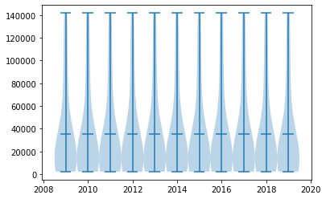

```python
er_list = []
for i in range(0,11):
    er_list.append(sumtable.iloc[0].values.tolist())

fig,ax = plt.subplots()
ax.violinplot(er_list,years,widths=1,showmeans=True)

plt.show()
```

This box plot below shows how different county has different school enrollment rate.

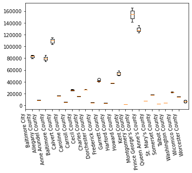

```python
counties = data.columns.values.tolist()
counties.remove('Grades')
counties.remove('Year')
counties.remove('Maryland')
counties
county_list= []
for (countyName, enrollData) in sumtable.iteritems():
    county_list.append(enrollData.values.tolist())

fig,ax = plt.subplots()
ax.boxplot(county_list)
plt.xticks(range(0,len(counties)),counties,rotation=100)
plt.show()
```

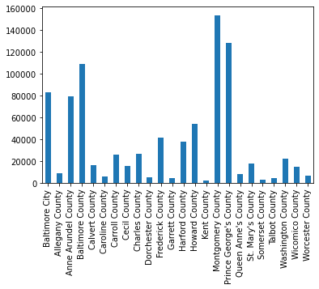

```python
sumtable.mean().plot(kind="bar")
plt.show()
```

Conclusion: based on all the anlaysis above, there is a clear relationship between county and time and school enrollment numbers. Bigger county would have more students and school enrollment numbers keep increasing over the time.